# TF-IDF & Weighted Log Odds to Analyze Research Abstracts

Julie Nguyen

Welcome to my journey as I prepare for my PhD comprehensive exam! Since starting my PhD in 2019, I’ve used text analysis to help me with various aspects of my research, including gearing up for comps. In this notebook, I analyze over a hundred research papers that explore two critical questions: how new ideas gain acceptance and how social networks influence the careers of men and women differently. These research streams, which I refer to as “Novelty Reception” and “Network and Gender”, form the bedrock of my work into the systemic barriers women face in creative fields.

We start by extacting detailed metadata for each paper from their academic citations. Then, we delve into the textual content of the abstracts, using NLP tools like TF-IDF and weighted log odds to unearth key terms and phrases unique to each research stream. We also create visualizations to further clarify the thematic trends we uncover.

Join me on this journey as we explore the thematic trends in the research on the forces shaping acceptance of new ideas and the gendered effects of social networks.

# Generating metadata from citations

I’ve set up a Google Sheets document that contains all the papers I plan to explore. Let’s pull this data from Google Sheets and see what we’ve got.

```r
# Importing a Google Sheets document containing the paper citations and abstracts
gsheet::gsheet2tbl('https://docs.google.com/spreadsheets/d/1ic1Zc3CpXZyiYfD5whrHLizMN83WXyxjipN5moUtVG8/edit#gid=0') -> reading

# Sample 10 random rows to preview the data structure
reading %>%
  sample_n(10) %>%
  # format the table for better visualization in HTML
  kbl(caption = "Sample of Reading List in Chronological Order") %>%
  kable_styling(bootstrap_options = c("striped", "hover", "responsive"), fixed_thead = TRUE) %>%
  scroll_box(width = "100%", height = "700px")
```

| Citation | Abstract | Topic |
| --- | --- | --- |
| Sternberg, R. J. (1985). Implicit theories of intelligence, creativity, and wisdom. Journal of personality and social psychology, 49(3), 607. | In a prestudy, a questionnaire was sent to 97 professors in the fields of art, business, philosophy, and physics; it was also given to 17 laypersons. Subjects were asked to list behaviors characterist… | Novelty reception |
| Boudreau, K. J., Guinan, E. C., Lakhani, K. R., & Riedl, C. (2016). Looking across and looking beyond the knowledge frontier: Intellectual distance, novelty, and resource allocation in science. Manage… | Selecting among alternative projects is a core management task in all innovating organizations. In this paper, we focus on the evaluation of frontier scientific research projects. We argue that the “i… | Novelty reception |
| Smith, E. B., Brands, R. A., Brashears, M. E., & Kleinbaum, A. M. (2020). Social networks and cognition. Annual Review of Sociology, 46, 159-174. | Social network analysis, now often thought of simply as network science, has penetrated nearly every scientific and many scholarly fields and has become an indispensable resource. Yet, social networks… | Network and gender |
| Zhao, E. Y., Fisher, G., Lounsbury, M., & Miller, D. (2017). Optimal distinctiveness: Broadening the interface between institutional theory and strategic management. Strategic Management Journal, 38(1… | Attaining optimal distinctiveness—positive stakeholder perceptions about a firm’s strategic position that reconciles competing demands for differentiation and conformity—has been an important focal po… | Novelty reception |
| Chan, C. R., & Parhankangas, A. (2017). Crowdfunding innovative ideas: How incremental and radical innovativeness influence funding outcomes. Entrepreneurship Theory and Practice, 41(2), 237-263. | We investigate the effect of innovativeness on crowdfunding outcomes. Because crowdfunding campaigns characterized by greater incremental innovativeness are more comprehensible and generate more user … | Novelty reception |
| Hofstra, B., Kulkarni, V. V., Galvez, S. M. N., He, B., Jurafsky, D., & McFarland, D. A. (2020). The diversity–innovation paradox in science. Proceedings of the National Academy of Sciences, 117(17), … | Prior work finds a diversity paradox: Diversity breeds innovation, yet underrepresented groups that diversify organizations have less successful careers within them. Does the diversity paradox hold fo… | Novelty reception |
| Brashears, M. E. (2008). Gender and homophily: Differences in male and female association in Blau space. Social Science Research, 37(2), 400-415. | Homophily, the tendency for similar individuals to associate, is one of the most robust findings in social science. Despite this robustness, we have less information about how personal characteristics… | Network and gender |
| Sgourev, S. V. (2013). How Paris gave rise to Cubism (and Picasso): Ambiguity and fragmentation in radical innovation. Organization Science, 24(6), 1601-1617. | In structural analyses of innovation, one substantive question looms large: What makes radical innovation possible if peripheral actors are more likely to originate radical ideas but are poorly positi… | Novelty reception |
| Wu, L., & Kane, G. C. (2021). Network-Biased Technical Change: How Modern Digital Collaboration Tools Overcome Some Biases but Exacerbate Others. Organization Science, 32(2), 273-292. | Using three years’ data from more than 1,000 employees at a large professional services firm, we find that adopting an expertise search tool improves employee work performance in billable revenue, whi… | Network and gender |
| Vásárhelyi, O., Zakhlebin, I., Milojević, S., & Horvát, E. Á. (2021). Gender inequities in the online dissemination of scholars’ work. Proceedings of the National Academy of Sciences, 118(39). | Unbiased science dissemination has the potential to alleviate some of the known gender disparities in academia by exposing female scholars’ work to other scientists and the public. And yet, we lack co… | Network and gender |

This sample gives us a quick snapshot of our data: each paper’s citation, abstract, and its assigned research stream—either ‘Novelty reception’ or ‘Network and gender’. Next, we’re going to add layers of detail to our dataset. We’ll extract and create metadata such as publication year, author names, and more, thus setting the stage for deeper analysis.

```r
# extract and create useful metadata for each paper
reading %>%
  rename(research_stream = Topic) %>%
  mutate(
  # create id for each paper based on the row number
  id = row_number(),

  # create publication year by extracting 4-letter words from citation that starts with 2 then 0 (i.e., articles published in the 21st century) or with 1 then 9 (i.e., articles published in the 20th century)
  year = str_extract_all(Citation, "[2][0][0-9]{2}|[1][9][0-9]{2}", simplify = T)[,1] %>% as.numeric(),

  # create decade based on year
  decade = (year %/% 10) * 10,
  decade = paste0(decade, "s"),

  # create authors by extracting all characters from citation that appear before the closing bracket )
  authors = str_replace(Citation, "\\).*$", ""),
  # remove the begining bracket ( from the above extracted text
  authors = str_replace(authors, "\\(", ""),

  # create journal by detecting journal names in citation
  journal = case_when(
      str_detect(Citation, regex("American Sociological Review", ignore_case = T)) ~ "ASR",
      str_detect(Citation, regex("Academy of Management journal", ignore_case = T)) ~ "AMJ",
      str_detect(Citation, regex("Academy of Management review", ignore_case = T)) ~ "AMR",
      str_detect(Citation, regex("Academy of Management discoveries", ignore_case = T)) ~ "Discoveries",
      str_detect(Citation, regex("Academy of Management Annals", ignore_case = T)) ~ "Annals",
      str_detect(Citation, regex("Academy of Management learning", ignore_case = T)) ~ "Learning",
      str_detect(Citation, regex("Administrative Science Quarterly", ignore_case = T)) ~ "ASQ",
      str_detect(Citation, "Management science") ~ "Management sci",
      str_detect(Citation, regex("American journal of sociology", ignore_case = T)) ~ "AJS",
      str_detect(Citation, "Scientific reports") ~ "Nature",
      str_detect(Citation, regex("nature", ignore_case = T)) ~ "Nature",
      str_detect(Citation, regex("Social forces", ignore_case = T)) ~ "Soc forces",
      str_detect(Citation, "Entrepreneurship Theory and Practice") ~ "ETP",

      # Soc net has to be after PSPB, annual review, jom, and Org Science because a few of papers in these journals have the phrase "social networks" in the title. Therefore, we have to categorize papers in PSPB, annual review, jom, and Org Science first, then assign the rest of the papers with the phrase "social networks" in citation to the journal Soc net
      str_detect(Citation, "Journal of Management") ~ "JoM",
      str_detect(Citation, regex("Organization Science", ignore_case = T)) ~ "Org Sci",

      str_detect(Citation, regex("annual", ignore_case = T)) ~ "Annual review",
      str_detect(Citation, regex("Social Networks", ignore_case = T)) ~ "Soc Net",
      str_detect(Citation, regex("Social Science Research", ignore_case = T)) ~ "Social science research",

      str_detect(Citation, regex("Journal of experimental social psychology", ignore_case = T)) ~ "JESP",
      str_detect(Citation, "Proceedings of the National Academy of Sciences") ~ "PNAS",
      str_detect(Citation, "Psychological review") ~ "Psyc review",
      str_detect(Citation, "Psychological science") ~ "Psyc science",
      str_detect(Citation, "Strategic Management Journal") ~ "SMJ",
      str_detect(Citation, "Journal of personality and social psychology") ~ "JPSP",
      str_detect(Citation, "Journal of Applied Psychology") ~ "JAP",
      str_detect(Citation, regex("Personality and Social Psychology Bulletin", ignore_case = T)) ~ "PSPB",

      str_detect(Citation, regex("Research Policy", ignore_case = T)) ~ "Research policy",
      str_detect(Citation, regex("\\bScience\\b", ignore_case = T)) ~ "Science",
      str_detect(Citation, regex("venturing", ignore_case = T)) ~ "JBV",
      str_detect(Citation, regex("consumer", ignore_case = T)) ~ "Consumer research",
      str_detect(Citation, regex("rationality", ignore_case = T)) ~ "Rationality",
      str_detect(Citation, regex("Social psychology quarterly", ignore_case = T)) ~ "Social psyc quarterly",
      str_detect(Citation, regex("Journal of Political Economy", ignore_case = T)) ~ "Journal of political economy",

      TRUE ~ "others"),

  # manually recode those that are book chapters by assigning papers with the words ugly, speading, and routledge in citation as book chapter
  journal = case_when(
    str_detect(Citation, paste(c("ugly", "spreading", "Routledge" ), collapse = '|')) ~ "book chapter",
    TRUE ~ as.character(journal)),

  # create fields based on journals
  field = case_when(
      journal == "AMJ" | journal == "Discoveries" | journal == "Annals" |
      journal == "AMR" | journal == "Learning" | journal == "ASQ" | journal == "Management sci" |
      journal == "JoM" | journal == "Org Sci" | journal == "SMJ" ~ "management",

      journal == "ASR" | journal == "AJS" | journal == "Soc forces" | journal == "Soc Net" ~ "sociology",

      journal == "Nature" | journal == "PNAS" | journal == "Science" ~ "science",

      journal == "ETP" | journal == "JBV" ~ "entrepreneurship",

      journal == "PSPB" | journal == "JESP" | journal == "Psyc review" | journal == "Psyc science" |
      journal == "JPSP" | journal == "JAP" ~ "psychology",

      journal == "Annual review" | journal == "book chapter" ~ "reviews and books",

      journal == "Research policy" | journal == "Consumer research" | journal == "Rationality" |
      journal == "Social psyc quarterly" | journal == "Social science research" |
      journal == "Journal of political economy" ~ "others"
  ),

  # get the title
  paper_title = str_extract(Citation, "\\).*$") %>% # extract all strings in citation that appears after the closing bracket
    str_replace("^\\S* ", "") %>% # remove everything from the beginning until the first white space
    str_replace("\\..*$", ""), # remove everything starting from the first period .

  # get the name of first author by extract the first word in the string variable Author
  first_author = word(authors, 1),

  # get the type of papers based on the journal
  type = case_when(journal == "Annals" | journal == "book chapter" | journal == "Annual review" |
                     journal == "JoM" |str_detect(paper_title, 'distinctiveness') ~ "review",

                   journal == "AMR" ~ "theory",

                   TRUE ~ "empirical"),

  method = case_when(str_detect(Abstract, regex("experiment", ignore_case = T)) |
                       str_detect(Citation, regex("experiment", ignore_case = T)) ~ "experiment",

                     TRUE ~ "others")
) %>%

  # merge name of first author with publication year to create abbreviated id for each paper, but still keep original column. Here the original column for first_author disappears because it is overwritten by the new first_author column, so only the original column for year remains in the data
  unite(first_author, c("first_author", "year"), sep = " ", remove = F) %>%

  # reorder columns so that id and year (the numeric variables) are the first two columns
  relocate(where(is.numeric), .before = where(is.character)) %>%
  relocate(paper_title, .after = id) %>%
  janitor::clean_names() -> reading

saveRDS(reading, "reading.rds")
```

Let’s take a look at our new dataset now.

```r
# generate a concise summary of the data
reading %>% skimr::skim()
```

Data summary

| Name | Piped data |
| --- | --- |
| Number of rows | 107 |
| Number of columns | 14 |
| _______________________ |  |
| Column type frequency: |  |
| character | 12 |
| numeric | 2 |
| ________________________ |  |
| Group variables | None |

**Variable type: character**

| skim_variable | n_missing | complete_rate | min | max | empty | n_unique | whitespace |
| --- | --- | --- | --- | --- | --- | --- | --- |
| category | 15 | 0.86 | 20 | 78 | 0 | 23 | 0 |
| paper_title | 0 | 1.00 | 14 | 160 | 0 | 107 | 0 |
| citation | 0 | 1.00 | 87 | 271 | 0 | 107 | 0 |
| abstract | 0 | 1.00 | 609 | 1765 | 0 | 107 | 0 |
| research_stream | 0 | 1.00 | 17 | 18 | 0 | 2 | 0 |
| first_author | 0 | 1.00 | 8 | 17 | 0 | 105 | 0 |
| decade | 0 | 1.00 | 5 | 5 | 0 | 6 | 0 |
| authors | 0 | 1.00 | 13 | 93 | 0 | 106 | 0 |
| journal | 0 | 1.00 | 3 | 28 | 0 | 33 | 0 |
| field | 0 | 1.00 | 6 | 17 | 0 | 7 | 0 |
| type | 0 | 1.00 | 6 | 9 | 0 | 3 | 0 |
| method | 0 | 1.00 | 6 | 10 | 0 | 2 | 0 |

**Variable type: numeric**

| skim_variable | n_missing | complete_rate | mean | sd | p0 | p25 | p50 | p75 | p100 | hist |
| --- | --- | --- | --- | --- | --- | --- | --- | --- | --- | --- |
| id | 0 | 1 | 54.93 | 31.90 | 1 | 27.5 | 54 | 82.5 | 109 | ▇▇▇▇▇ |
| year | 0 | 1 | 2014.23 | 8.53 | 1958 | 2012.0 | 2017 | 2019.0 | 2021 | ▁▁▁▁▇ |

We now have more details for each paper such as the authors, publication year, and journal, among others.

Now that our dataset is shaped up, let’s dive into some specific analyses. We’ll start by visualizing the number of theoretical papers, empirical papers, and review papers I have on my reading list.

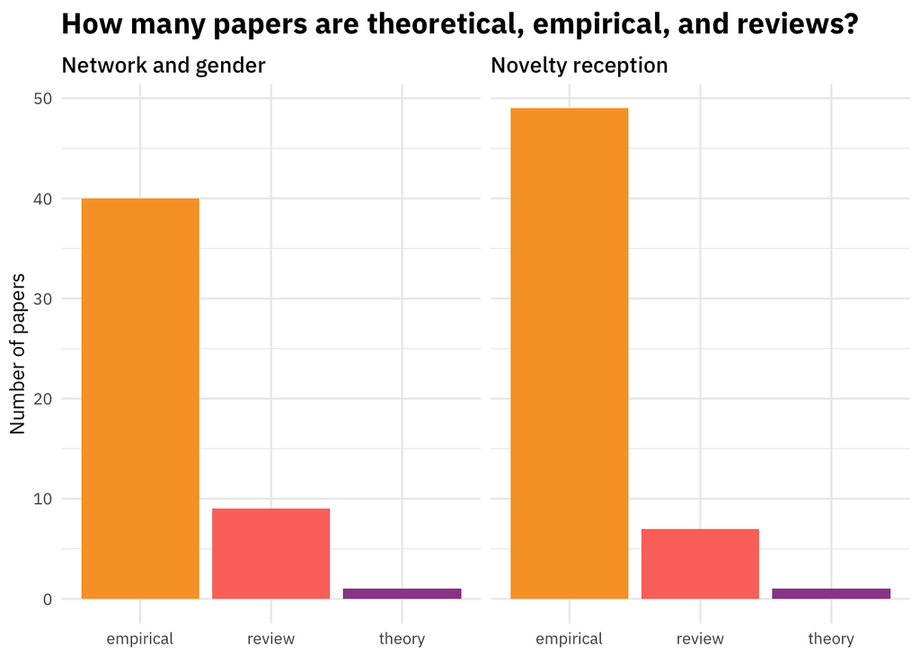

```r
# Analyzing the distribution of paper types across research streams
reading %>%
  # Grouping data by research stream for aggregated counts by paper type
  group_by(research_stream) %>%
  # Counting occurrences of each paper type and sorting by count
  count(type, sort = T) %>%
  ungroup() %>%
  # Reordering 'type' based on descending count for better visualization
  mutate(type = reorder(type, -n)) %>%
  # specifying type as the x axis, count as the y axis, each type of paper will have a different color
  ggplot(aes(type, n, fill = type)) +
  # create bar chart
  geom_col(show.legend = FALSE) +
  # graph for each research stream
  facet_wrap(~ research_stream) +
  # customizing color for each type of paper
  scale_fill_manual(values = c("#F9A12EFF", "#FC766AFF", "#9B4A97FF")) +
  # setting up labels and title for the plot
  labs(x = NULL,
       y = "Number of papers",
       title = "How many papers are theoretical, empirical, and reviews?")
```

```r
  # theme(plot.title = element_text(size=15))
```

From the charts, it’s clear most of my readings are empirical papers, while review and theoretical papers are fewer. This makes sense given my focus on data-driven research.

Next, let’s examine the diversity of publication venues, sorted by fields within each research stream. This will help us understand where most research in my reading list is being published.

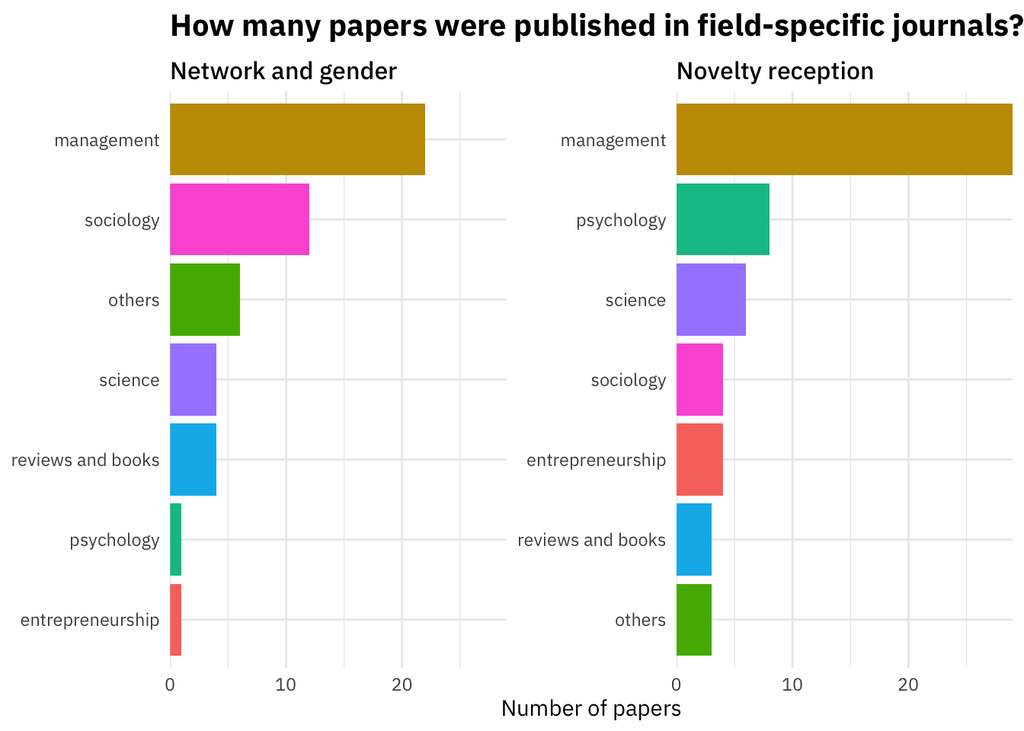

```r
# Examining the publication venues by field within each research stream
reading %>%
  group_by(research_stream) %>%
  # Counting papers by field and sorting by count
  count(field, sort = T) %>%
  ungroup()  %>%
  # Reordering fields within each research stream based on count for coherent visual ordering
  mutate(field_1 = field,
         field = reorder_within(field, n, research_stream)
         ) %>%
  # Creating a bar chart with flipped coordinates for better label visibility
  ggplot(aes(field, n, fill = field_1)) +
  geom_col(show.legend = FALSE) +
  # Using reordered scale for the x-axis and adjusting y-axis scale
  scale_x_reordered() +
  facet_wrap(~ research_stream, scales = "free_y") +
  coord_flip() +
  scale_y_continuous(expand = c(0,0)) +
  labs(y = "Number of papers",
       x = NULL,
       title = "How many papers were published in field-specific journals?") +
  theme(plot.title = element_text(size = 15))
```

It turns out a significant number of papers come from management journals, which makes sense since I’m doing a PhD in management. Two other types of journals that I also read quite a lot is sociology and psychology journals, although sociology papers here are mostly about network and gender, whereas psychology papers are mostly about novelty reception.

What about the number of papers across time?

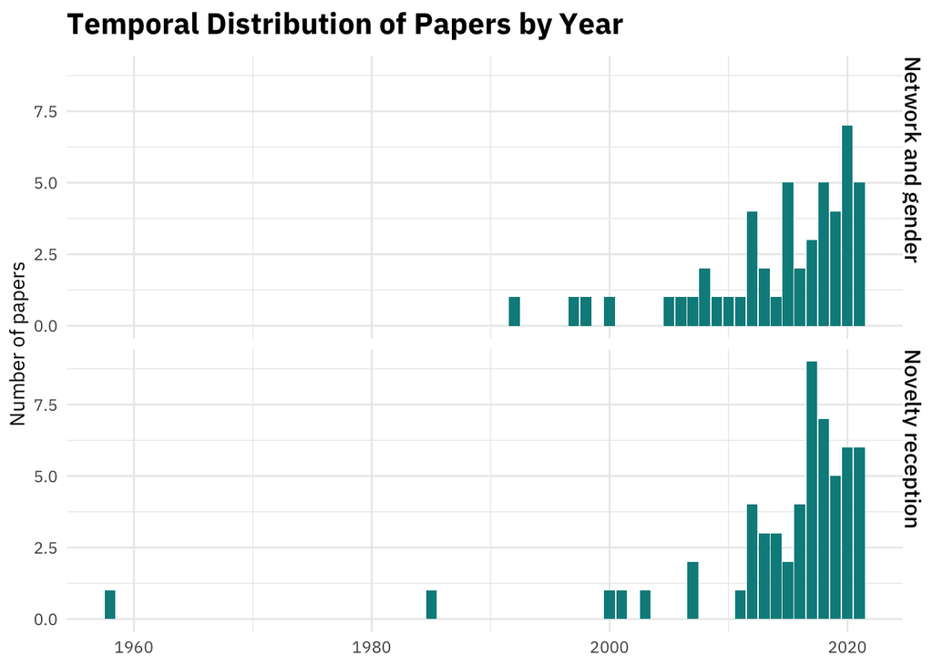

```r
# Analyzing the temporal distribution of papers
reading %>%
  # Counting papers by publication year and topic, sorting by count
  count(year, research_stream, sort= T) %>%
  ggplot(aes(year, n)) +
  geom_col(show.legend = FALSE, fill = "cyan4") +
  # Faceting by research stream to see trends within each area of interest
  facet_grid(rows = vars(research_stream)) +
  labs(y = "Number of papers", x = NULL, title = "Temporal Distribution of Papers by Year")
```

It appears that most of the papers on my list were published within the last 10 years. The few papers published before 2000 must be the seminal papers on the topics I study.

I have also created a variable for the decade a paper was published in, which gives us a broader grouping than year. Let’s see how many papers in my list each decade has.

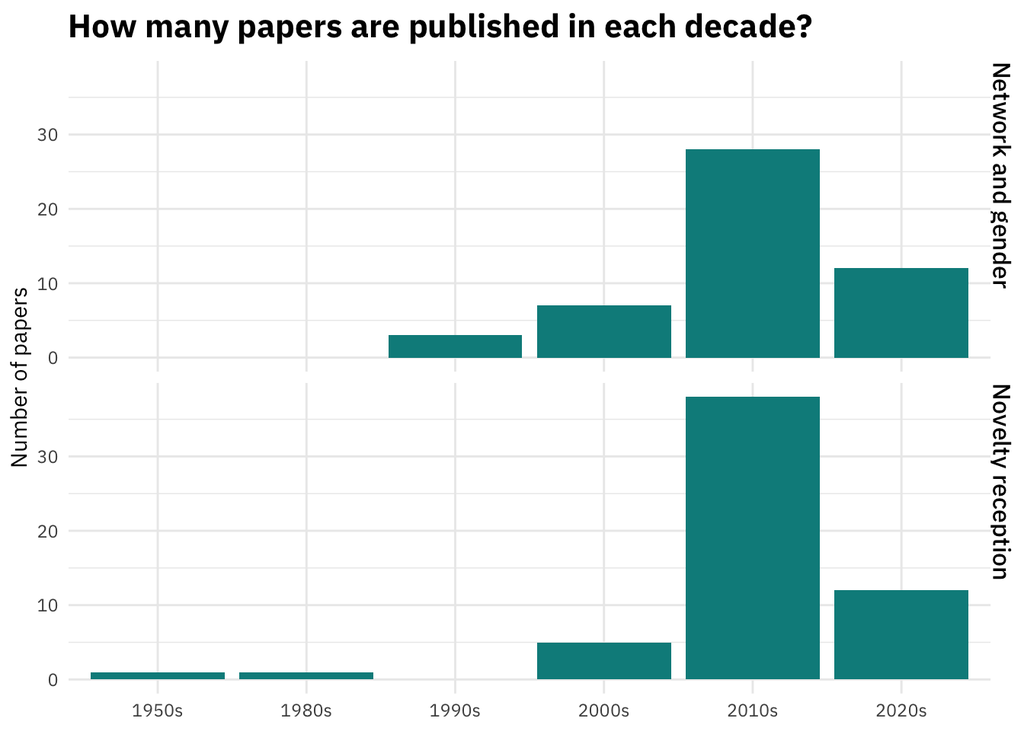

```r
# Exploring the distribution of papers across decades
reading %>%
  # Counting papers by decade and research stream, sorting by count
  count(decade, research_stream, sort = T) %>%
  # Sorting decades in descending order for visual coherence
  arrange(desc(readr::parse_number(decade)))  %>%
  # Creating a column chart to visualize the number of papers per decade
  ggplot(aes(decade, n, group = 1)) +
  geom_col(show.legend = FALSE, fill = "cyan4") +
  # graph for each research stream
  facet_grid(rows = vars(research_stream)) +
  labs(x = NULL,
       y = "Number of papers",
       title = "How many papers are published in each decade?")
```

# Cleaning and tokenizing paper abstracts

Now that our dataset is properly formatted, let’s dive into some exploratory text analysis of the abstracts from our collection of papers. First, let’s transform the text into a tidy format, clean it up by removing common stop words and numbers, and ensure consistency by converting plural nouns into their singular forms.

```r
# Preliminary Text Analysis

# Preparing the abstracts for text analysis by tokenizing the text and cleaning it.
reading_unnest <- reading %>%
  # Selecting only the ID and abstract text columns for analysis
  select(id, abstract) %>%
  # Tokenizing abstracts into individual words
  unnest_tokens(word, abstract) %>%
  # Removing common English stop words to focus on relevant terms
  anti_join(get_stopwords()) %>%
  # Filtering out tokens that are numeric as they likely do not contribute to thematic analysis
  filter(!str_detect(word, "[0-9]+")) %>%
  # Normalizing plural words to their singular form to consolidate word forms
  mutate(word = case_when(str_detect(word, "[^e|aies$]ies$") ~ str_replace(word, "ies$", "y"),
                          str_detect(word, "[^e|a|oes$]es$") ~ str_replace(word, "es$", "e"),
                          str_detect(word, "[^ss$|us$]s$") ~ str_remove(word, "s$"),
                          TRUE ~ word))
```

# Finding most frequent words and phrases

Now that our abstracts are tidied up, let’s find out which words pop up most frequently. This helps us understand the dominant terms that shape the discussions in our collected papers.

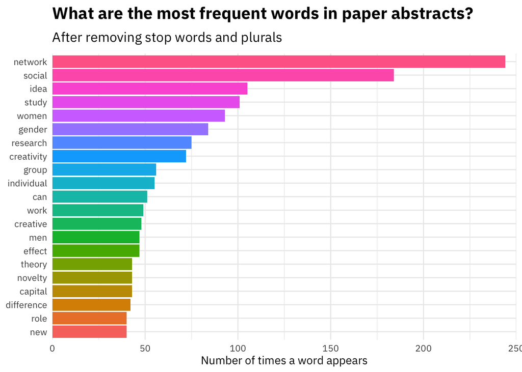

```r
## Analysis of Most Frequent Words
reading_unnest %>%
  # Count occurrences of each word and sort in descending order
  count(word, sort = T) %>%
  # Focus on the top 20 most frequent words
  slice_max(n, n = 20)%>%
  # Reorder words for plotting based on their count
  mutate(word = reorder(word, n)) %>%
  # Create a bar plot of word frequencies
  ggplot(aes(word, n, fill = word)) +
  geom_col(show.legend = FALSE) +
  coord_flip() +
  scale_y_continuous(expand = c(0, 0), limits = c(0, 250)) +
  labs(x = NULL, y = "Number of times a word appears",
       title = "What are the most frequent words in paper abstracts?",
       subtitle = "After removing stop words and plurals")
```

Next, we turn our attention to bigrams to uncover common word pairs that give us deeper insights into the themes prevalent in the abstracts. This analysis reveals how certain concepts are typically discussed together in paper abstracts.

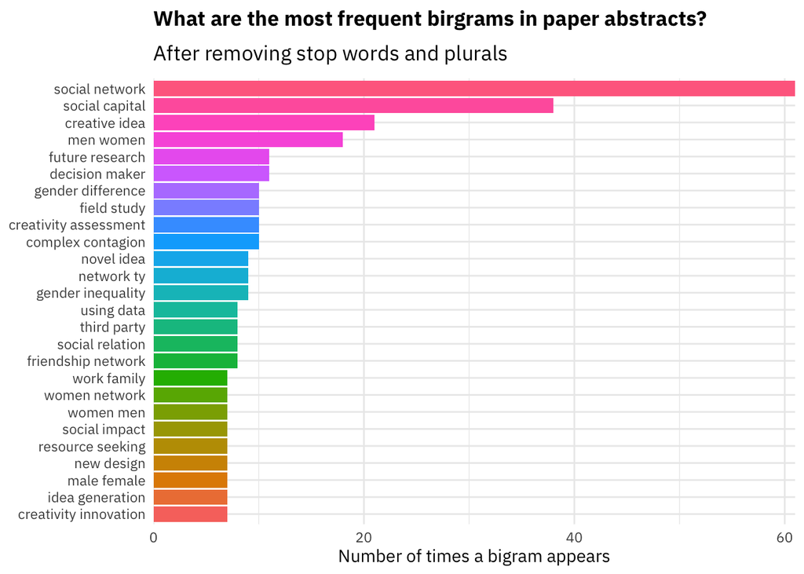

```r
## Analysis of Most Frequent Bigrams
reading_unnest %>%
  # Converting long-format data to a wide format to facilitate bigram creation
  group_by(id) %>%
  mutate(ind = row_number()) %>%
  ungroup() %>%
  pivot_wider(id,
              names_from = ind,
              values_from = word) %>%
  # Replace missing values with an empty space for text cohesion
  mutate_all(replace_na, " ") %>%
  # merge one-word columns together to form a continuous text for each abstract
  unite(col = abstract_ns,
        -id,
        sep = " ",
        remove = T) %>%
  # break the text into bigrams
  unnest_tokens(bigram, abstract_ns, token = "ngrams", n = 2) -> reading_unnest_bigrams

# visualizing the most frequent bigrams
reading_unnest_bigrams %>%
  # count the number of times a bigram appears in the corpus
  count(bigram, sort = TRUE) %>%
  # get the 20 most frequent bigrams
  slice_max(n, n = 20) %>%
  # arrange bigrams based on frequency count
  mutate(bigram = reorder(bigram, n)) %>%
  ggplot(aes(bigram, n, fill = bigram)) +
  geom_col(show.legend = FALSE) +
  coord_flip() +
  scale_y_continuous(expand = c(0, 0)) +
  labs(x = NULL,
       y = "Number of times a bigram appears",
       title = "What are the most frequent birgrams in paper abstracts?",
       subtitle = "After removing stop words and plurals") +
  theme(plot.title = element_text(size = 13))
```

The most frequently appearing words are “network”, “social”, “idea”, “study”, “women” and “gender”. The most common bigrams are “social network”, “social capital”, “creative ideas”, “men women”. This aligns perfectly with my research focus on the impact of social networks and the evaluation of creative ideas, especially in how these dynamics differ between men and women in professional settings.

Let’s drill down further and analyze the most frequent unigrams and bigrams within each specific research stream. This will help us pinpoint the key topics and discussions prevalent in each stream, providing a clearer picture of their thematic directions.

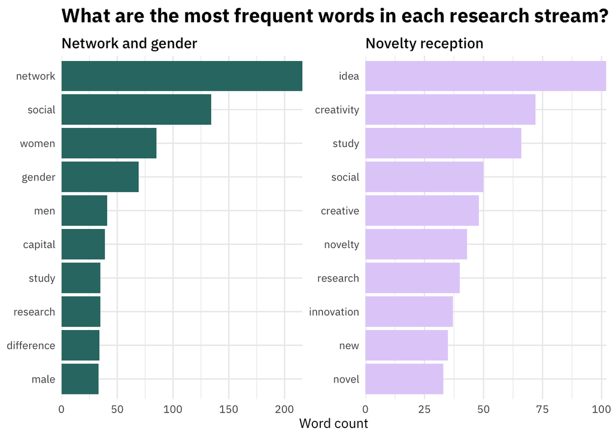

```r
# Analyzing most frequent unigrams by topic
reading_unnest %>%
  # Joining research stream information to the unigrams
  left_join(reading %>% select(id, research_stream)) %>%
  count(research_stream, word, sort = TRUE) %>%
  group_by(research_stream) %>%
  # Selecting top 10 words in each research stream
  top_n(10) %>%
  ungroup() %>%
  # need to reorder_within() because ggplot otherwise would order the words (which is typed character) alphabetically. reorder_within() orders the words based on its frequency. Here "word" is what we want to order, "n" is what we want to order by, and "Topic" is the group we want to reorder within
  ggplot(aes(reorder_within(word, n, research_stream),
             n,
             fill = research_stream)) +
  geom_col(show.legend = FALSE) +
  scale_x_reordered() +
  coord_flip() +
  facet_wrap(~research_stream, scales = "free") +
  scale_y_continuous(expand = c(0, 0)) +
  scale_fill_manual(values = c("#317773", "#E2D1F9")) +
  labs(y = "Word count", x = NULL, title = "What are the most frequent words in each research stream?")
```

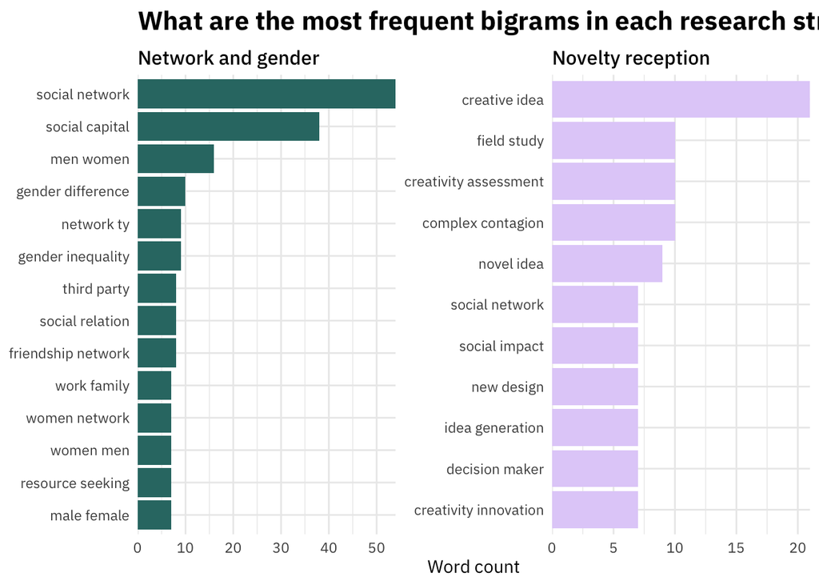

```r
# Repeating the process for bigrams
reading_unnest_bigrams %>%
  mutate(id = as.numeric(id)) %>%
  left_join(reading %>% select(id, research_stream) ) %>%
  count(research_stream, bigram, sort = TRUE) %>%
  group_by(research_stream) %>%
  top_n(10) %>%
  ungroup() %>%
  # need to reorder_within() because ggplot otherwise would order the words (which is typed character) alphabetically. reorder_within() orders the words based on its frequency. Here "word" is what we want to order, "n" is what we want to order by, and "Topic" is the group we want to reorder within
  ggplot(aes(reorder_within(bigram, n, research_stream),
             n,
             fill = research_stream)) +
  geom_col(show.legend = FALSE) +
  scale_x_reordered() +
  coord_flip() +
  facet_wrap(~research_stream, scales = "free") +
  scale_y_continuous(expand = c(0, 0)) +
  scale_fill_manual(values = c("#317773", "#E2D1F9")) +
  labs(y = "Word count", x = NULL, title = "What are the most frequent bigrams in each research stream?")
```

# Highlighting distinctive terms with TF-IDF and weighted log odds

## TF-IDF

While frequent word counts can tell us a lot, they don’t always give the full picture. That’s where Term Frequency-Inverse Document Frequency (TF-IDF) comes into play. TF-IDF helps us identify words that are not only common in a specific document but also rare across the entire document corpus, enhancing their significance. This method decreases the weight for words that occur frequently across documents, and increases the weight for words that are rare, highlighting unique aspects of each text.

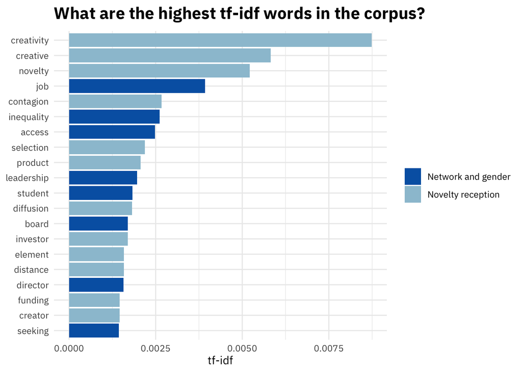

```r
# Calculating TF-IDF to identify uniquely important words
reading_unnest %>%
  # Joining research stream data to each word
  left_join(reading %>% select(id, research_stream)) %>%
  # Counting occurrences of each word within each research stream
  count(research_stream, word, sort = T) %>%
   # Calculating tf-idf for each word within research streams
  bind_tf_idf(word, research_stream, n) -> reading_tfidf

# Plotting the top 20 words with the highest tf-idf scores to identify uniquely important words
reading_tfidf %>%
  # Select the top 20 words with the highest tf-idf scores
  top_n(20) %>%
  # Reordering words based on tf-idf score for better visual representation
  mutate(word = reorder(word, tf_idf)) %>%
  ggplot(aes(word, tf_idf, fill = research_stream)) +
  # create bar chart
  geom_col() +
  # flip the x and y axis to better display word labels
  coord_flip() +
  # Adjusting text size for clarity
  theme(strip.text=element_text(size=11)) +
  # Set custom colors for each research stream
  scale_fill_manual(values = c("#0063B2FF", "#9CC3D5FF")) +
  # Adding labels and title to the chart
  labs(x = NULL, fill = NULL, y = "tf-idf",
       title = "What are the highest tf-idf words in the corpus?")
```

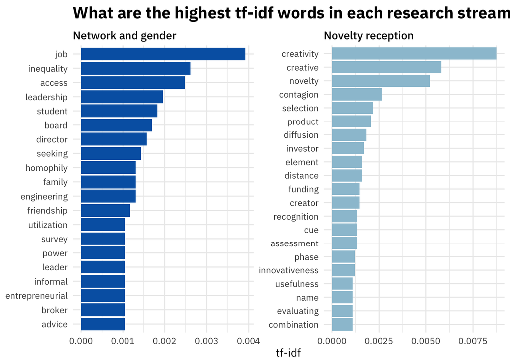

```r
# Plotting the highest tf-idf words within each research stream to explore their specific vocabulary
reading_tfidf %>%
  group_by(research_stream) %>%
  top_n(20) %>%
  ungroup() %>%
  # reorder words based on tf-idf within each topic
  mutate(word = reorder_within(word, tf_idf, research_stream)) %>%
  # create graph of words and their tf-idf
  ggplot(aes(word, tf_idf, fill = research_stream)) +
  # create bar chart
  geom_col(show.legend = FALSE) +
  # create graph for each topic
  facet_wrap(~ research_stream, scales = "free") +
  # reorder axis within facets
  scale_x_reordered() +
  # flip the x and y axis for better readability
  coord_flip() +
  theme(strip.text=element_text(size=11)) +
  scale_fill_manual(values = c("#0063B2FF", "#9CC3D5FF")) +
  labs(x = NULL, y = "tf-idf",
       title = "What are the highest tf-idf words in each research stream?")
```

```r
# Remove the tf-idf dataframe from memory to free up resources
rm(reading_tfidf)
```

For papers focused on network and gender, words like “job,” “inequality,” “access,” “leadership,” “student,” and “board” stand out. These terms underline the study’s focus on career access, leadership roles, and the dynamics of inequality within professional settings. On the other hand, novelty reception papers frequently mention words such as “creativity,” “creative,” “novelty,” “contagion,” “selection,” and “product,” which reflect the discourse on how creative products are recognized, selected, and spread within the field.

This TF-IDF analysis helps us identify key themes and terms that define each research stream more effectively than mere frequency counts. It showcases the distinct language tied to different areas of study, providing us with a deeper understanding of the thematic underpinnings of the research.

## Weighted log odds

Beyond frequency counts and TF-IDF, another compelling method to examine how words differ across groups is the weighted log odds ratio. This measure adjusts for word frequency across different documents and is particularly effective when we’re interested in pinpointing words that uniquely characterize each group. Unlike TF-IDF, which considers only the presence of words across documents, weighted log odds take into account the actual frequency, providing a more nuanced understanding of word importance.

Let’s start by identifying words in our corpus that have the highest weighted log odds, which will help us understand which terms are especially prominent in one research stream compared to others.

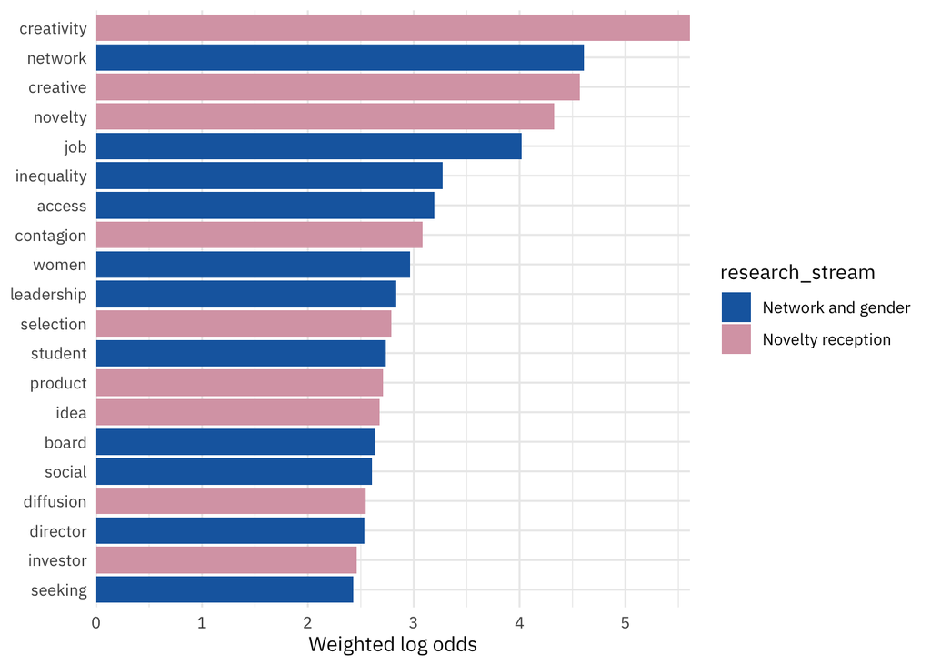

```r
# Calculating Weighted Log Odds for Word Frequencies Across Research Streams
reading_unnest %>%
  left_join(reading %>% select(id, research_stream)) %>% # Merging research stream information with the word data
  count(research_stream, word, sort = T) %>% # Counting the frequency of each word per research stream
  tidylo::bind_log_odds(research_stream, word, n) -> reading_log_odds # Calculating weighted log odds

# Plotting the Words with the Highest Weighted Log Odds
reading_log_odds %>%
  slice_max(log_odds_weighted, n = 20) %>% # Selecting the top 20 words with highest weighted log odds
  ggplot(aes(log_odds_weighted, reorder(word, log_odds_weighted), fill = research_stream)) +
  geom_col() + # Creating a bar chart
  scale_fill_manual(values = c("#1868ae", "#d9a5b3")) + # Custom color palette
  scale_x_continuous(expand = c(0, 0)) + # Adjusting the x-axis scale for better display
  labs(x = "Weighted log odds", y = NULL) # Labeling the axes
```

Now, let’s break down the highest weighted log odds words by each research stream to better capture their specific vocabulary.

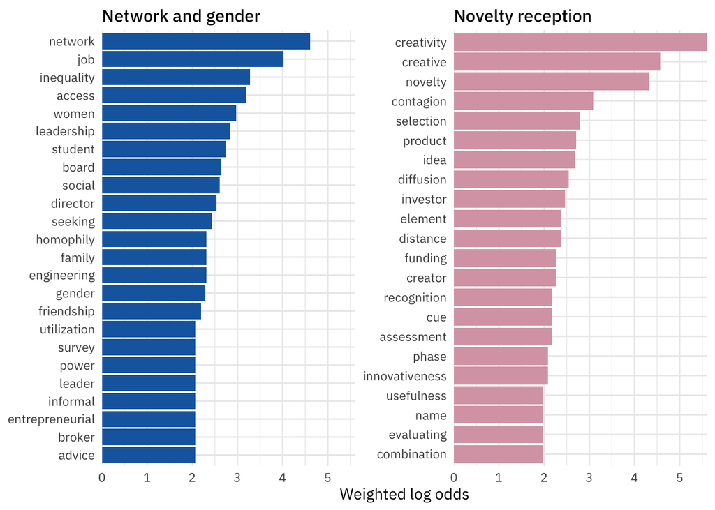

```r
reading_log_odds %>%
  group_by(research_stream) %>%
  slice_max(log_odds_weighted, n = 20) %>% # Filtering the top 20 distinct words in each research stream
  ungroup() %>%
  ggplot(aes(log_odds_weighted,
             reorder_within(word, log_odds_weighted, research_stream),
             fill = research_stream)) +
  geom_col(show.legend = FALSE) +
  facet_wrap(~research_stream, scales = "free_y") + # Creating a separate plot for each research stream
  scale_y_reordered() + # Creating a separate plot for each research stream
  scale_fill_manual(values = c("#1868ae", "#d9a5b3")) +
  scale_x_continuous(expand = c(0, 0)) +
  labs(x = "Weighted log odds", y = NULL)
```

To delve deeper, let’s graph the weighted log odds of each word against its frequency in the context of ‘Network and Gender’ research.

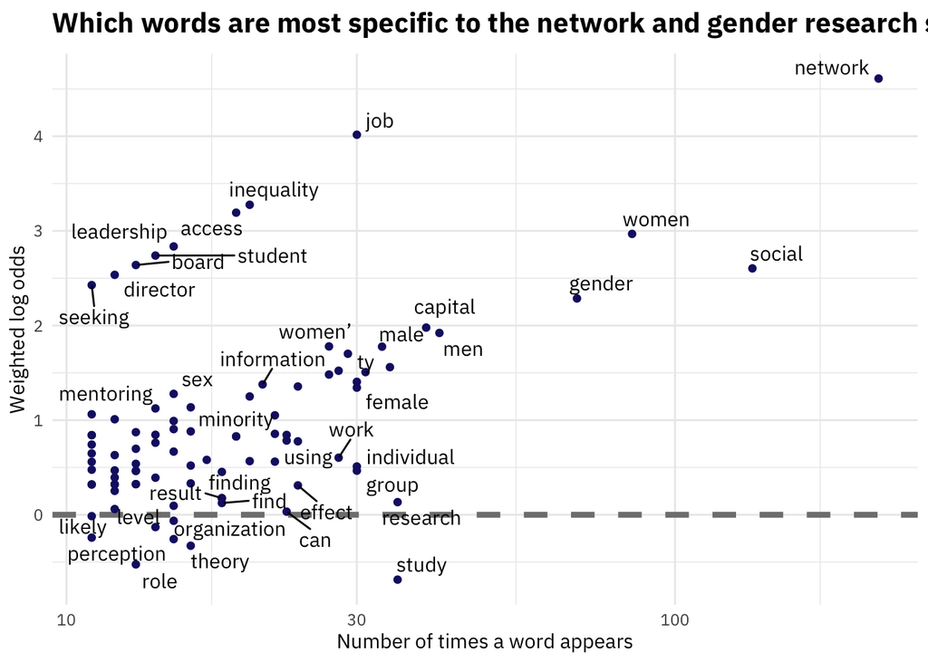

```r
# Specific Word Analysis in the Context of Gender and Network Topics
reading_log_odds %>%
  filter(str_detect(research_stream, "gender"), n > 10) %>% # Filtering for words in the 'gender' stream with sufficient frequency
  ggplot(aes(n, log_odds_weighted, label = word)) +
  geom_hline(yintercept = 0, color = "gray50", lty = 2, size = 1.5) + # Adding a reference line at 0 for neutral log odds
  geom_point(color = "midnightblue") + # Plotting points
  ggrepel::geom_text_repel(family = "IBMPlexSans") + # Adding labels to points
  scale_x_log10() + # Logarithmic scale for x-axis to handle wide data range
  labs(x = "Number of times a word appears",
       y = "Weighted log odds",
       title = "Which words are most specific to the network and gender research stream?") +
  theme(plot.title = element_text(size = 15))
```

From this graph, it seems that terms like “network” and “social” are particularly prevalent in ‘Network and Gender’ papers, highlighting their focus on social structures. Conversely, words like “study” are common but less distinctive since they appear frequently across both research streams.

Similarly, we can analyze the ‘Novelty Reception’ stream to identify which terms are uniquely significant there.

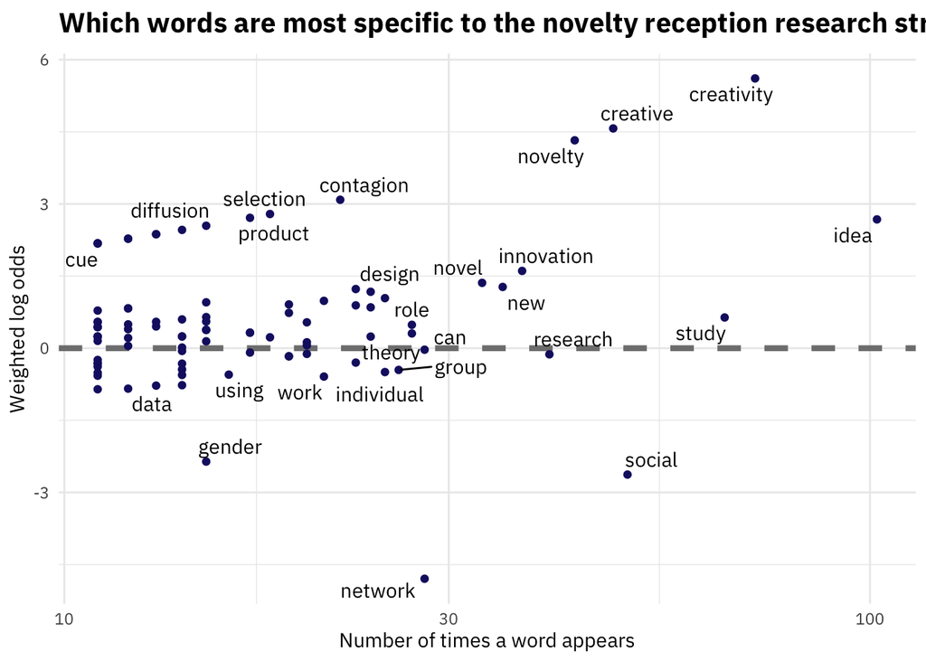

```r
reading_log_odds %>%
  filter(str_detect(research_stream, "reception"), n > 10) %>%
  ggplot(aes(n, log_odds_weighted, label = word)) +
  geom_hline(yintercept = 0, color = "gray50", lty = 2, size = 1.5) +
  geom_point(color = "midnightblue") +
  ggrepel::geom_text_repel(family = "IBMPlexSans") +
  scale_x_log10() +
  labs(x = "Number of times a word appears",
       y = "Weighted log odds",
       title = "Which words are most specific to the novelty reception research stream?") +
  theme(plot.title = element_text(size = 15))
```

```r
# Clean up the created data frame to free up memory
rm(reading_log_odds)
```

In the ‘Novelty Reception’ papers, “idea” is the most frequently occurring words, but it is not as unique to this stream as “creativity” because it is also frequently used in the ‘Network and Gender’ stream too. Also, “social” and “network” are used quite often in this stream, but they are used much more often in the ‘Network and Gender’ stream and as such has a negative weighted log odds.

# Conclusion and next steps

In this notebook, we’ve analyzed over a hundred research papers within two key areas: “Novelty Reception” and “Network and Gender.” We started by extracting important information from each paper’s references, such as the authors, publication year, and journal. Then, using TF-IDF and weighted log odds, we analyzed the texts to uncover the most significant words and phrases in discussions about how innovative ideas are accepted and how social networks influence the careers of men and women differently. We’ve presented these findings visually to make the trends and themes easier to understand.

Looking ahead, our next step is to apply topic modeling to these paper abstracts. This will help us identify and understand the main themes discussed across the papers in more detail, enhancing our understanding of the scholarly conversations on novelty reception and network and gender.